# victor fossaluza - Pesquisa Google

[figure not shown]

Aproximadamente 6.270 resultados (0,52 segundos)

Looking for results in English?

Configurações de idioma

## Resultados da pesquisa

### [Currículo Lattes - Plataforma Lattes - CNPq](http://lattes.cnpq.br/7608013990240863)

lattes.cnpq.br/7608013990240863

- Similares

### [Victor Fossaluza | Facebook](https://pt-br.facebook.com/victor.fossaluza)

https://pt-br.facebook.com/**victor**.**fossaluza**

- [Em cache](http://webcache.googleusercontent.com/search?q=cache:zuBA7ugsMG0J:https://pt-br.facebook.com/victor.fossaluza+&cd=2&hl=pt-BR&ct=clnk&gl=br)
- Similares

*Victor Fossaluza* está no Facebook. Participe do Facebook para se conectar com *Victor Fossaluza* e outros que você talvez conheça. O Facebook oferece às...

### [Victor Fossaluza | LinkedIn](https://br.linkedin.com/pub/victor-fossaluza/32/b84/429)

https://br.linkedin.com/pub/**victor**-**fossaluza**/32/b84/429

São Paulo Area, Brazil - Professor Doutor do Departamento de Estatística - IME-USP

Visualize o perfil profissional de *Victor Fossaluza* (Brasil) no LinkedIn. O LinkedIn é a maior rede de negócios do mundo, que ajuda profissionais como Victor ...

### [PDF][Testes de hipóteses em eleiç˜oes majoritárias Victor ...](http://www.teses.usp.br/teses/disponiveis/45/45133/tde-03092008-151708/publico/VictorFossaluza.pdf)

www.teses.usp.br/teses/disponiveis/45/45133/tde.../**VictorFossaluza**.pdf

- Similares

de V Fossaluza - 2008 - [Citado por 6](https://scholar.google.com.br/scholar?gws_rd=cr,ssl&um=1&ie=UTF-8&lr&cites=9538048204287312624) - [Artigos relacionados](https://scholar.google.com.br/scholar?gws_rd=cr,ssl&um=1&ie=UTF-8&lr&q=related:8AIZm070XYT76M:scholar.google.com/)

### [Victor Fossaluza - ResearchGate](http://www.researchgate.net/profile/Victor_Fossaluza)

www.researchgate.net/profile/**Victor**_**Fossaluza**

- [Em cache](http://webcache.googleusercontent.com/search?q=cache:V67lRYlL0CEJ:www.researchgate.net/profile/Victor_Fossaluza+&cd=5&hl=pt-BR&ct=clnk&gl=br)

Researcher » *Victor Fossaluza*, University of São Paulo, Department of Mathematics (IME) (São Paulo), Brazil, Statistics, Probability Theory and Logic and ...

### [Victor Fossaluza - Info - ResearchGate](http://www.researchgate.net/profile/Victor_Fossaluza/info)

www.researchgate.net/profile/**Victor**_**Fossaluza**/info

Hospital das Clínicas da Faculdade de Medicina da Universidade de São Paulo · Departamento de Psiquiatria · PROTOC. Brazil · São Paulo ...

1. Imagens de victor fossaluzaDenunciar imagens

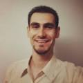

   Mais imagens para victor fossaluza

### [Victor Fossaluza - Google Scholar Citations](http://scholar.google.com.br/citations?user=hYgjs4AAAAAJ&hl=en)

scholar.google.com.br/citations?user=hYgjs4AAAAAJ&hl=en

- [Em cache](http://webcache.googleusercontent.com/search?q=cache:aTCWW1XOUzUJ:scholar.google.com.br/citations%3Fuser%3DhYgjs4AAAAAJ%26hl%3Den+&cd=12&hl=pt-BR&ct=clnk&gl=br)
- Similares

Professor of Statistics, University of São Paulo - usp.br

*Victor Fossaluza* ... LA Conrado, AG Hounie, JB Diniz, V Fossaluza, AR Torres, EC Miguel, . ... ACG Nakata, JB Diniz, AR Torres, MA De Mathis, V Fossaluza, .

### [Victor Fossaluza - YouTube](https://www.youtube.com/user/victorspsc)

https://www.youtube.com/user/**victor**spsc

- [Em cache](http://webcache.googleusercontent.com/search?q=cache:wyqtODmZJwUJ:https://www.youtube.com/user/victorspsc+&cd=13&hl=pt-BR&ct=clnk&gl=br)

Love this tune by Clean Bandit. Enjoy Rather Be, everyone! :) Lead Vocals: Morgan James, Additional... *Victor Fossaluza* subscribed to a channel 2 months ago ...

### [Victor Fossaluza – IME USP ~ III Semana da Estatística ...](http://sestufscar.blogspot.com/p/palestrante-victor-fossaluza-ime-usp.html)

sestufscar.blogspot.com/p/palestrante-**victor**-**fossaluza**-ime-usp.html

- [Em cache](http://webcache.googleusercontent.com/search?q=cache:XTf21hsFQ-8J:sestufscar.blogspot.com/p/palestrante-victor-fossaluza-ime-usp.html+&cd=14&hl=pt-BR&ct=clnk&gl=br)

Alocação Intencional. Nos cursos de planejamento e amostragem mais “ortodoxos”, vistos durante a graduação, é sugestionado que a amostra deve ser ...

### Pesquisas relacionadas a victor fossaluza

victor fossaluza **lattes**

victor fossaluza **ime usp**

[output not shown]

[Mais](http://www.google.com.br/intl/pt-BR/options/)